# Função para Tunar modelo de XGBoost

## Motivação

Este material foi feito inspirado pelo curso de R para Machine Learning, ministrado pela [Curso-R](https://curso-r.com/), em que mostra uma heurística sobre a tunagem do Modelo de XGBoost. O material está disponível para qualquer pessoa [neste link](https://curso-r.github.io/202006-intro-ml/), baixando o arquivo `exemplos/12-xgboost.Rmd`.

## O que é XGBoost?

O modelo de [XGBoost](https://curso-r.github.io/main-intro-ml/slides/03-modelos-de-arvores.html#31) é uma extensão do Gradiente Boost, que é um modelo baseado em árvores. Se você deseja entender melhor o que é isso, sugiro [este material](https://brunaw.com/slides/satrday-sp/tidyverse-para-AM.html#1) e o repositória que está exposto nele.

Bom, o XGBoost conta com sete hiperparâmetros para encontrarmos a melhor combinação de um modelo. De que forma fazemos isso? Através da tunagem dos hiperparâmeros. Porém, quanto maior o número destes, mais demorado será a execução do modelo e maior capacidade computacional você vai precisar.

Se tivéssemos uma máquina com memória infinita, poderíamos testar infinitas possibilidades de hiperparâmetros para encontrarmos os melhores possíveis. No entando, sabemos que: uma máquina infinita custa infinitos dinheiros (R$) e ainda sim não conseguiria testar infinitas combinações e; se rodarmos em nuvem infinitamente isso, pode nos gerar também uma quantia absurda.

Com isso, foram criadas diversar maneiras de executar essa tunagem, e aqui, vou expor, em forma de função, a maneira que aprendi no curso que fiz, como falei anteriormente.

## Porque uma função para tunar XGBoost?

Muitas vezes, no nosso dia a dia, estamos bem atarefados com nossos afazeres. Na minha experiência pessoal, sempre gosto de entender melhor qualquer situação problema que vem até mim, cada particularidade e cada circunstância. No entando, isso nem sempre é possível. Com isso, algo que me facilite a execução deste processo de tunagem foi bem pertinente.

Outro motivo que me fez montar essa função, foi o fato de que sempre é bom ter um “chute inicial” para os nossos trabalhos. Como já dizia o filósofo: *Nada se cria, tudo se copia*. Resumindo, com esta função tenho bons hiperparâmetros iniciais para que, caso eu queira, posteriormente, conseguir ajustar meu modelo.

## Modelagem

Sem mais delongas, agora vamos a um teste de modelagem com a função de tunagem do XGBoost. Caso queira ter acesso a ela, só baixar o script e utilizar a função `source("nome do arquivo")` no seu script de modelagem.

### Base trabalhada

Como sou da área de People Analytics, trabalharei com uma base que utilizo sempre de funcionários de uma empresa, onde contém informações de colaboradores desligados e ativos da mesma. Como este não é o foco deste material, não vamos nos aprofundar nas questões fora da função de tunagem.

Abaixo temos as variáveis trabalhadas e suas informações de estrutura:

```r
base <- rio::import("../Case_Turnover_v2.csv")

base %>%
  select_if(is.numeric) %>%
    skimr::skim()
```

Data summary

| Name | Piped data |
| --- | --- |
| Number of rows | 14999 |
| Number of columns | 8 |
| _______________________ |  |
| Column type frequency: |  |
| numeric | 8 |
| ________________________ |  |
| Group variables | None |

**Variable type: numeric**

| skim_variable | n_missing | complete_rate | mean | sd | p0 | p25 | p50 | p75 | p100 | hist |
| --- | --- | --- | --- | --- | --- | --- | --- | --- | --- | --- |
| nivel_satisfacao | 0 | 1 | 0.61 | 0.25 | 0.09 | 0.44 | 0.64 | 0.82 | 1 | ▃▅▇▇▇ |
| ultima_avaliacao | 0 | 1 | 0.72 | 0.17 | 0.36 | 0.56 | 0.72 | 0.87 | 1 | ▂▇▆▇▇ |
| atuacao_projetos | 0 | 1 | 3.80 | 1.23 | 2.00 | 3.00 | 4.00 | 5.00 | 7 | ▇▆▃▂▁ |
| horas_trabalhadas | 0 | 1 | 201.05 | 49.94 | 96.00 | 156.00 | 200.00 | 245.00 | 310 | ▃▇▆▇▂ |
| tempo_empresa | 0 | 1 | 3.50 | 1.46 | 2.00 | 3.00 | 3.00 | 4.00 | 10 | ▇▃▁▁▁ |
| licenca_medica | 0 | 1 | 0.14 | 0.35 | 0.00 | 0.00 | 0.00 | 0.00 | 1 | ▇▁▁▁▂ |
| desligado | 0 | 1 | 0.24 | 0.43 | 0.00 | 0.00 | 0.00 | 0.00 | 1 | ▇▁▁▁▂ |
| promocao_ultimos_3_anos | 0 | 1 | 0.02 | 0.14 | 0.00 | 0.00 | 0.00 | 0.00 | 1 | ▇▁▁▁▁ |

```r
base %>%
  select_if(is.character) %>%
    skimr::skim()
```

Data summary

| Name | Piped data |
| --- | --- |
| Number of rows | 14999 |
| Number of columns | 2 |
| _______________________ |  |
| Column type frequency: |  |
| character | 2 |
| ________________________ |  |
| Group variables | None |

**Variable type: character**

| skim_variable | n_missing | complete_rate | min | max | empty | n_unique | whitespace |
| --- | --- | --- | --- | --- | --- | --- | --- |
| area | 0 | 1 | 2 | 11 | 0 | 10 | 0 |
| salario | 0 | 1 | 4 | 7 | 0 | 3 | 0 |

Em um processo normal de estudo, jamais passaria para a próxima etapa sem antes fazer uma boa análise exploratória, a fim de entender as variáveis que estão na base e trabalhar possíveis tratamentos das mesmas.

### Pré processamento

```r
base <- base %>%
  mutate(
    desligado = as.factor(desligado)
  )

set.seed(100)
treino_teste <- base %>%  initial_split(0.7, strata = desligado)

base_treino <- training(treino_teste)
base_teste <- testing(treino_teste)

# Data prep
base_recipe <- recipe(
  desligado ~., data = base_treino
) %>%
  step_zv(all_predictors()) %>%
  step_modeimpute(all_nominal(), -all_outcomes()) %>%
  step_medianimpute(all_numeric()) %>%
  step_novel(all_nominal(), -all_outcomes()) %>%
  step_dummy(all_nominal(), -all_outcomes())
```

No final do processo nossa base ficará assim:

```r
# veirficar como ficou
juice(prep(base_recipe)) %>% head() %>% knitr::kable()
```

| nivel_satisfacao | ultima_avaliacao | atuacao_projetos | horas_trabalhadas | tempo_empresa | licenca_medica | promocao_ultimos_3_anos | desligado | area_comercial | area_executivos | area_financeiro | area_marketing | area_medica | area_pessoas | area_producao_ac | area_supply | area_TI | area_new | salario_baixo | salario_mediano | salario_new |
| --- | --- | --- | --- | --- | --- | --- | --- | --- | --- | --- | --- | --- | --- | --- | --- | --- | --- | --- | --- | --- |
| 0.10 | 0.77 | 6 | 247 | 4 | 0 | 0 | 1 | 1 | 0 | 0 | 0 | 0 | 0 | 0 | 0 | 0 | 0 | 1 | 0 | 0 |
| 0.89 | 1.00 | 5 | 224 | 5 | 0 | 0 | 1 | 1 | 0 | 0 | 0 | 0 | 0 | 0 | 0 | 0 | 0 | 1 | 0 | 0 |
| 0.38 | 0.54 | 2 | 143 | 3 | 0 | 0 | 1 | 1 | 0 | 0 | 0 | 0 | 0 | 0 | 0 | 0 | 0 | 1 | 0 | 0 |
| 0.41 | 0.46 | 2 | 128 | 3 | 0 | 0 | 1 | 0 | 0 | 1 | 0 | 0 | 0 | 0 | 0 | 0 | 0 | 1 | 0 | 0 |
| 0.09 | 0.62 | 6 | 294 | 4 | 0 | 0 | 1 | 0 | 0 | 1 | 0 | 0 | 0 | 0 | 0 | 0 | 0 | 1 | 0 | 0 |
| 0.38 | 0.49 | 2 | 151 | 3 | 0 | 0 | 1 | 0 | 0 | 0 | 0 | 0 | 0 | 1 | 0 | 0 | 0 | 1 | 0 | 0 |

### Carregamento da função

Agora vamos carregar a função que está em um script em meu diretório.

```r
source("../Function_XGBoost_output.R")
```

Após isso, basta utilizarmos a função {tunagem_xgb()}, que tem os argumentos `base_treino` e `base_recipe` (esta é a base pré-processada). Ela pedirá o número de folds que você deseja repartir sua base para validação cruzada.

Obs: para este exemplo já deixei selecionada o número de folds fixo em 5, mas no script é o usuário quem define.

```r
tunagem_xgb(base_treino, base_recipe)
```

```
[1] "Agora vamos rodar os hiperparâmetros!"
[1] "Melhores hiperparâmetros: "
[1] "Lean_rate =  0.05"
[1] "Trees =  100"
[1] "Tree_depth =  6"
[1] "Min_n =  5"
[1] "Loss_reduction =  0.1"
[1] "Sample_size =  1"
[1] "Mtry =  0.3"
[1] "Seu modelo está pronto para ser testado!"
[1] "Utilize o objeto xgb_wk para o teste do modelo"
```

Como podem ver, esta função vai retornar os valores dos melhores hiperparâmetros e salvar o objeto `xgb_wkf`, que nada mais é que o workflow (objeto que carrega todos os elementos do modelo) utilizado na modelagem. Precisaremos deste objeto para tetar nosso modelo.

### Teste do modelo

Após utilização da função, vamos testar nosso modelo com o objeto `xgb_wkf`, como disse anteriormente:

```r
xgb_last_fit <- xgb_wkf %>%
  last_fit(
    split = treino_teste,
    metrics = metric_set(roc_auc, accuracy)
  )
```

### Resultados do modelo

Agora saberemos as métricas do nosso modelo e a verificação da curva ROC. Aqui utilizei acurácia e auroc, mas claro que isso fica a critério de cada um:

```r
collect_metrics(xgb_last_fit) %>% knitr::kable()
```

| .metric | .estimator | .estimate | .config |
| --- | --- | --- | --- |
| accuracy | binary | 0.9639248 | Preprocessor1_Model1 |
| roc_auc | binary | 0.9744340 | Preprocessor1_Model1 |

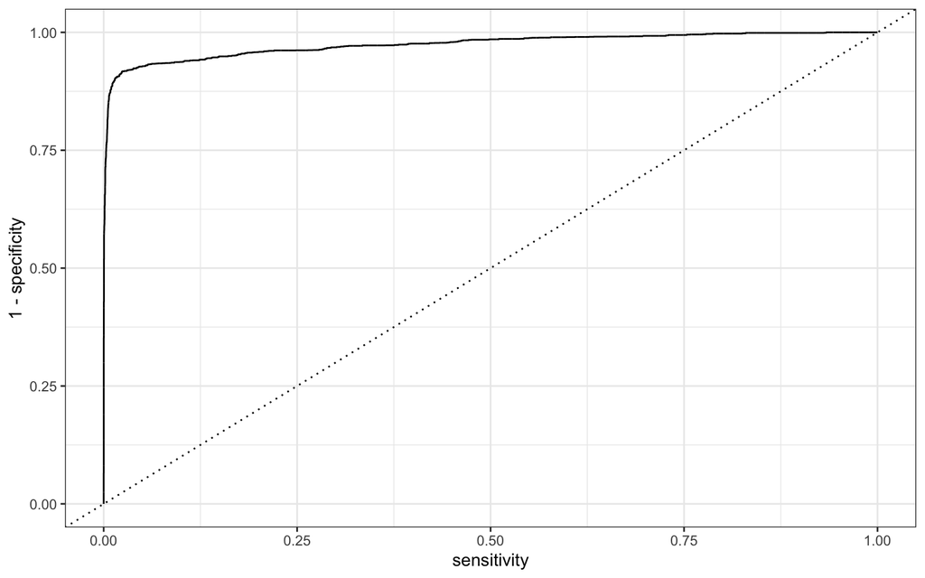

```r
# curva roc
xgb_last_fit %>%
  collect_predictions() %>%
  roc_curve(desligado,`.pred_1`) %>%
  autoplot() +
  coord_flip()
```

Também conseguimos verificar a importância das variáveis do modelo:

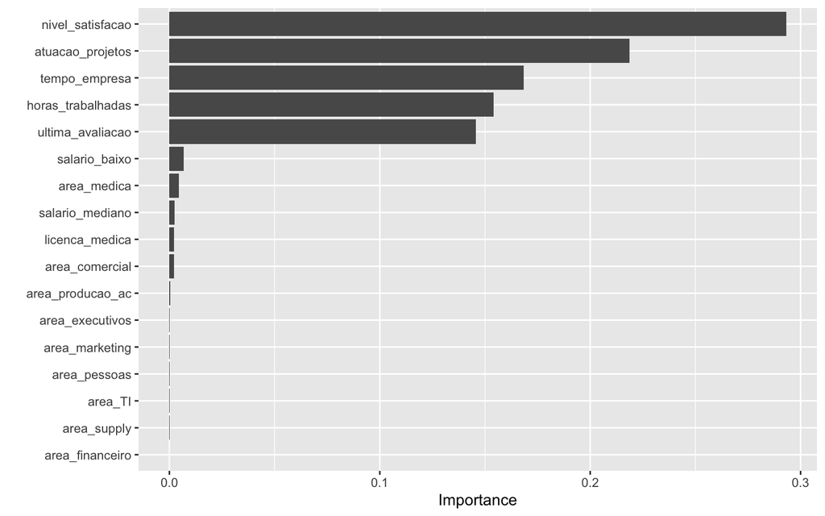

```r
xgb_last_fit %>%
  pluck(".workflow", 1) %>%
  pull_workflow_fit() %>%
  vip::vip(num_features = 20)
```

Após este processo todo, você pode salvar este modelo e utilizar como quiser!

## Considerações

Este material serve para quem deseja aplicar o processo de tunagem dos hiperparâmetros do modelo de XGBoost de maneira mais simples e quem sabe conseguir um bom chute inicial destes argumentos. Não recomendo aplicar a função diretamente a uma base, sem a análise exploratória e sem conhecimento prévio dos hiperparâmetros. No mais, aceito contribuições, sugestões e críticas! Pode acessar [meu Github](https://github.com/rodrigoest93) ou [meu Linkedin](https://www.linkedin.com/in/rodrigoalmeidafigueira/).